# Modelado de proteínas por homología

**Autores: Jocelyn Cheé Santiago y Andrés Jiménez Kaufmann**

## Objetivo

El objetivo de esta práctica es generar un par de modelos protéicos para una secuencia que ya conocemos (sabemos su estructura) y compararlos con su estructura real para ver qué tanto se aleja la predicción de la realidad. Para saber la calidad del modelo utilizaremos el DOPE score, compararemos el sobrelape con la estructura real con MAMMOTH y evaluaremos el RMSD de los modelos.

## Instrucciones

##### 1) Elige una secuencia S de la superfamilia que elegiste para la tarea 3.

Se eligió la secuencia de 1ezvd1 Citocromo bc1 de levadura.

##### 2) Usando HHpred (http://toolkit.tuebingen.mpg.de/hhpred) selecciona al menos una estructura molde o template que puedas usar para modelar S, asegurándote que tiene menos del 90% de identidad si fuera posible.

Se eligió el séptimo hit que es la entrada 1vyd que es Citocromo C2 de *Rhodobacter capsulatus* que tiene una identidad de 20%.

La identidad se mantuvo baja para que, en el caso de obtener una buena predicción, sea mayormente basado en la estructura y no en la secuencia (como concluímos en la actividad 3, modelar por estructura es mejor que modelar por secuencia)

##### 3) De acuerdo con el ejemplo de http://eead-csic-compbio.github.io/bioinformatica_estructural/node34.html y la documentación de MODELLER construye dos modelos M1 y M2 de S y comprueba su estima de calidad con DOPE.

- Alineamiento a partir del cual se generaron los Modelos:

>P1;1vyd structureX:1vyd:2 :A:116 :A:::: DAAKGEKEFNK-CKTCHSIIAPDGTEIVKGAKT---------------------GPNLYGVVGRTA-------------- --------GTYP-EFKYKDSIVALGASGFAWTEEDIATYVKD-P------------GAFLKEKLDDKKAK--TEMAFKLA KGG--------------E-DVAAYLASVVK* >P1;query sequence:query:::::::0.00: 0.00 SIRRGYQVYREVCAACHSLDRV------AWRTLVGVSHTNEEVRNMAEEFEYDDEPDEQGNPKKRPGKLSDYIPGPYPNE QAARAANQGALPPDLSLIVKARH---GGCDYIFSLLTGY-PDEPPAGVALPPGSNYNPYFP--------GGSIAMARVLF DDMVEYEDGTPATTSQMAKDVTTFLNWCAE*

El DOPE score del modelo uno fue: -9596.15918

El DOPE del modelo dos fue: -10088.11816

Ambos scores fueron buenos ya que el error asociado a esos DOPE scores es de aproximadamente 5A lo cual nos puede brindar una muy buena idea de la estructura de una proteína.

##### 4) Evalúa la calidad de los modelos M obtenidos comparándolos con la estructura conocida, que descargaste de SCOP en la tarea 3. Para ello puedes usar MAMMOTH. En tu informe por favor indica el alineamiento obtenido, el RMSD y al menos una imagen de su superposición para brevemente comentar las diferencias que observas entre cada modelo y la estructura experimental.

- Cálculo de RMSD:

  Para calcular RMSD utilizamos los alineamientos de MAMMOTH y los PDB tanto de la estructura experimental como el de las predicciones.

**Estructura experimental vs Modelo 1**

- Alineamiento con Mammoth:

_______________________________________________________________________________ T U R B O M A M M O T H MAtching Molecular Models Obtained from THeory _______________________________________________________________________________ ------------------- Input information ------------------- ==> PREDICTION: Filename: query.B99990001.pdb Number of residues: 172 ==> EXPERIMENT: Filename: d1evzvd1.pdbd Number of residues: 199 ----------------------------- Structural Alignment Scores ----------------------------- PSI(ini)= 88.37 NALI= 152 NORM= 172 RMS= 15.78 NSS= 86 PSI(end)= 31.98 NALI= 55 NORM= 172 RMS= 3.92 Sstr(LG)= 1015.44 NALI= 55 NORM= 172 RMS= 3.92 E-value= 0.40691275E-02 Z-score= 5.4267227 -ln(E)= 5.5043267 ---------------------------- Final Structural Alignment ---------------------------- *** ********** ***** Prediction .......... .......... .......SIR RGYQVYREVC AACHS..... Prediction ---------- ---------- -------HHH HHHHHHHHHH H--SS----- ||| |||||||||| || Experiment HHHHHHHHHH HHHH-SSS-- --HHHHHHHH HHHHHHHHHH H--HHHHHHH Experiment MTAAEHGLHA PAYAWSHNGP FETFDHASIR RGYQVYREVC AACHSLDRVA *** ********** ***** Prediction ...LDRVAW. .....RTLVG VSHTNEEVRN MAEEFEYDDE PDEQGNPKKR Prediction -------HH- -----HHHHH HHHHHHHHHH HH---SSSSS -----SSSS- ||||| ||||| ||||| ||||| ||| | Experiment HHHHH---HH HHHHHHHHHH H$HHHHHH--- --SSSS---S S--------- Experiment WRTLVGVSHT NEEVRNMAEE FEYDDEPDEQ GNPKKR...P GKL......S ** ** ******* * **** ** * Prediction PGKLSDYIPG PYPNEQAARA ANQGALPPDL SLIVKARHGG CDYIFSLLTG Prediction ---SSSSSS- -------SSS SSS------- SS---SSS-- SSS--HHHHH ||| |||||| | ||| ||||| | Experiment -SSSSSSSS- -SSSS----- -------SSS S--SSSSS-- HHHHHHHHHH Experiment DYIPGPYPNE QAARAANQGA .......LPP DLSLIVKARH GGCDYIFSLL ** ** ******* * **** ** * *** ** ** * * Prediction YPDEPPAGVA LPPGSNYNPY FPGGSIAMA. ..RVLFDDMV EYEDGTPATT Prediction HHHH---SSS -----SSS-- -SS----HH- --HHHHHHHH HHHH-----S | | | ||| | | ||||||| ||||||||| Experiment HHHHHH---H H---SS---- SS-------H HHHHHHHHHH HHH-----SS Experiment TGYPDE...P PAGVALPPGS NYNPYFPGGS IAMARVLFDD MVEYEDGTPA *** ** ** * * ***** ** ** Prediction SQMAKDVTTF LNWCA.. Prediction S-------HH HHHHH-- |||| Experiment ---HHHHHHH HHHHHHH Experiment TTSQMAKDVT TFLNWCA ***** ** ** --------- Timings --------- < Initialization: 0.012 sec > < Secondary Structure assignment 0.000 sec > < Structure alignment: 0.032 sec > < Tertiary structure matching: 0.008 sec > < Text Output 0.000 sec > NORMAL_EXIT

- Imagen en Rasmol:

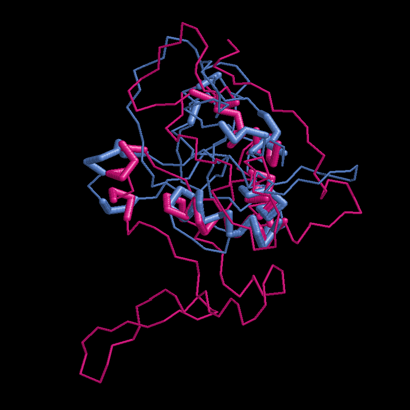

```python
from IPython.display import Image

Image(filename="/home/ajimenez/LCG/4Sem/Bioinfo/Semana2/tarea4/Modelo1vsrealidad.png")
```

- Valor de RMSD = 17.60 Angstrom
- Observaciones:

  Sabemos que citocromos son proteínas pertenecientes a un grupo más grande que es de sólo alfa-hélices. Esperaríamos observar que la predicción tienen un buen sobrelape con las estructuras hélicas ya que ésta es la principal característica de citocromo. En efecto, como podemos observar en la imagen el mayor sobrelape se observa en las zonas helicales. Ocurre lo contrario con zonas de loop que como podemos observar sobrelapan poco o nada.

**Esctructura exprimental vs Modelo 2**

- Alineamiento:

_______________________________________________________________________________ T U R B O M A M M O T H MAtching Molecular Models Obtained from THeory _______________________________________________________________________________ ------------------- Input information ------------------- ==> PREDICTION: Filename: query.B99990002.pdb Number of residues: 172 ==> EXPERIMENT: Filename: d1evzvd1.pdbd Number of residues: 199 ----------------------------- Structural Alignment Scores ----------------------------- PSI(ini)= 87.21 NALI= 150 NORM= 172 RMS= 16.18 NSS= 93 PSI(end)= 30.81 NALI= 53 NORM= 172 RMS= 3.86 Sstr(LG)= 1033.05 NALI= 53 NORM= 172 RMS= 3.86 E-value= 0.54941456E-02 Z-score= 5.1052699 -ln(E)= 5.2040722 ---------------------------- Final Structural Alignment ---------------------------- *** ********** ***** Prediction .......... .......... .......SIR RGYQVYREVC AACHS..... Prediction ---------- ---------- -------HHH HHHHHHHHHH H--SS----- ||| |||||||||| || Experiment HHHHHHHHHH HHHH-SSS-- --HHHHHHHH HHHHHHHHHH H--HHHHHHH Experiment MTAAEHGLHA PAYAWSHNGP FETFDHASIR RGYQVYREVC AACHSLDRVA *** ********** ***** Prediction ...LDRVAWR TLVGVSHTNE EVRNMAEEFE YDDEPDEQGN PKKRPGKLSD Prediction --------SS SSSSSSSSS- --SSSS---S SSSS----SS -------SSS || ||| | ||| ||||| ||||| | Experiment HHHHH---HH HHHHHHHHHH H------HHH HHH------- -----SSSSS Experiment WRTLVGVSHT NEEVRNMAEE F......EYD DEPDE..... ..QGNPKKRP ** *** * ******** Prediction YIPGPYPNEQ AARAANQGAL PPDLSLIVKA RHGGCDY... IFSLLTGYPD Prediction SSSS------ --SSSS---- ----SS---S SS--SSS--- ---HHHHHHH ||||||| ||| || | || |||||||||| Experiment S----SSSSS SSS--SSSS- ----SSSS-- SSSSS--HHH HHHHHHHHHH Experiment GKLSDYIPGP YPNEQAARAA NQGALPPDLS LIVKARHGGC DYIFSLLTGY ** *** * ******** *** ********** ***** * * Prediction E....PPAGV ALPPGSNYNP YFPGGSIAMA RVLFDDMVEY EDGTPATTSQ Prediction H-----SSSS ----SSSSS- ---SSS---S SSSSSSSSSS S-------SS | |||| || | |||||||||| | || |||| || Experiment HHHHH---SS ----S--S-- -----HHHHH HHHHH----- -HHHH----- Experiment PDEPPAGVAL PPGSN..YNP YFPGGSIAMA RVLFD..... .DMVEYEDGT *** ********** ***** * * * Prediction MAKDVTTFLN WCA...... Prediction SSS-HHHHHH HHH------ |||||| Experiment SS---HHHHH HHHHHHHHH Experiment PATTSQMAKD VTTFLNWCA * --------- Timings --------- < Initialization: 0.008 sec > < Secondary Structure assignment 0.000 sec > < Structure alignment: 0.016 sec > < Tertiary structure matching: 0.004 sec > < Text Output 0.000 sec > NORMAL_EXIT

- Imagen en Rasmol

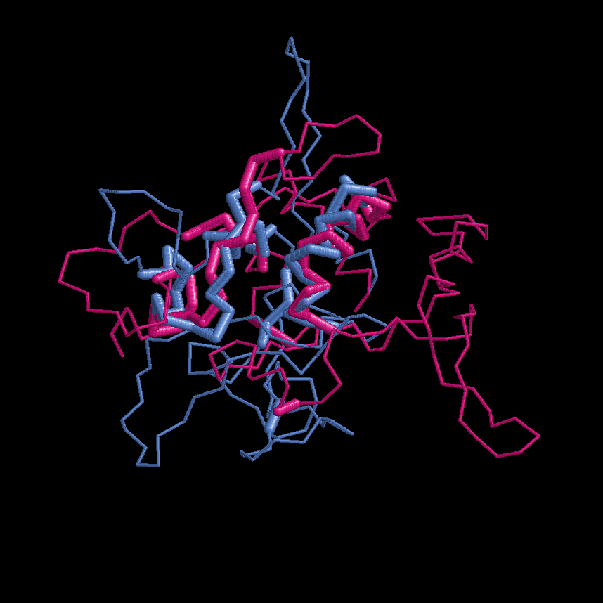

```python
Image(filename="/home/ajimenez/LCG/4Sem/Bioinfo/Semana2/tarea4/Modelo2vsrealidad.png")
```

- RMSD = 17.66 Angstrom
- Observaciones: Una vez más podemos observar que las zonas que mejor sobrelape tienen son las regiones de alfa-hélices y las de peor sobrelape son en las zonas loop.

## Discusión :

### Discrepancia entre valores DOPE y RMSD:

Los valores SCOPE que obtuvimos están asociados a un error de aproximadamente 5 Angstroms, sin embargo no hay que perder de vista que el modelo fue hecho en base a una proteína que tiene tan solo 20% de identidad con la proteína original. Por lo tanto, cuando se comparan las predicciones hechas en base al templado con su estructura original, el error aumenta de manera significativa.

Los valores de RMSD tan altos que obtuvimos se debe a las zonas no conservadas de la estructura, entonces el error se acumula y llega a valores altos.

### Las regiones conservadas sobrelapan:

La proteína que analizamos es perteneciente a la superfamilia de las citocromo, caracterizadas por la presencia de sólo alfa-hélices. La proteína que sirvió como templado es citocromo C2 de *Rhodobacter capsulatus*, no es sorpresa que la región de álfa hélice haya tenido buen sobrelape. Es notable que se pudo obtener un buen modelo, al menos en lo que respecta a las alfa hélices, a pesar de que la secuencia templado sea tan lejana evolutivamente, ésto habla de una gran constricción funcional de dicha estructura.

## Conclusiones:

Se pueden obtener buenos modelos de proteínas por medio de homología estructural aunque el organismo de la proteína templado esté sumamente alejado (tan lejano como dominios diferentes) del organismo de la proteína de interés.

La calidad o utilidad de la predicción dependerá exclusivamente de la pregunta que se intente responder. Si se pretende crear anotaciones estructurales y funcionales a partir de éstas predicciones habrá que ser muy crítico en la elección de la proteína templado y en el valor DOPE que resulte de éstos ya que como vimos, el error se propagará al compararse con la estructura real de la proteína de interés y nos puede brindar resultados no tan útiles para anotar secuencias.